# Ejercicio de Clase - Creditos - Notas 3 - pag 43

### Paquetes requeridos para correr el ejercicio

```r
install.packages("R2OpenBUGS")
install.packages("R2jags")
library(R2OpenBUGS)
library(R2jags)

#-Working directory-
wdir<-"/Users/guillemontanari/ITAM/github/GLM2016/JAGS-Ejercicio1"
setwd(wdir)
```

### 1) Sea  la tasa de créditos hipotecarios otorgados por un banco. Durante el 2004 la tasa promedio fue de 60% y la desviación estándar de la tasa fue de 0.04. En lo que va del año 2005 se han solicitado 100 créditos, de los cuales se han otorgado únicamente 50.

Esto quiere decir que tengo como INFORMACION INICIAL lo siguiente:

$x1,...,xn$ es una m.a. proveniente de una dist Bernoulli (exito=otorgado, fracaso=no otorgado)

$f(\theta)$ Distribución Inicial

$n=100$ la muestra que tengo hoy, de los cuales se han aprobado 50.

$\sum xi=50$ Este es un estadistico, la suma de las Xis

Además me dicen: en la historia del Banco, la tasa promedio fué del 60% y la desviación de 0.04.

$E(\theta)= 0.6$

$\sigma(\theta)= 0.04$

#### Determina la distribución inicial de referencia.

Esto consiste en utilizar una distribucion inicial de referencia para $\theta$

Cual es la distribucion de referencia de una Beta dado un modelo Bernoulli?

Consulto el formulario - Análisis Inferenciales - Si mis datos son Ber entonces mi distribucion inicial de referencia es una Beta(.5,.5)

```r
#--- Ejemplo 1---
#-Reading data-
n<-100
credito<-c(rep(1,n/2),rep(0,n/2))
#-Defining data-
data<-list("n"=n,"x"=credito)
#-Defining inits-
inits<-function(){list(theta=0.5, x1=rep(1,2))}
#-Selecting parameters to monitor-
parameters<-c("theta","x1")
#-Running code-
#JAGS
ej1.sim<-jags(data,inits,parameters,model.file="Ej1_c.txt",
              n.iter=5000,n.chains=1,n.burnin=500,n.thin=1)
```

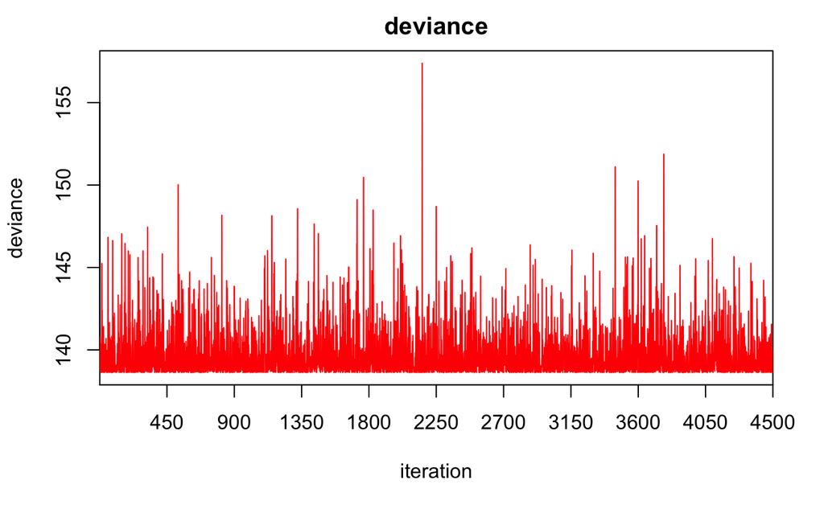

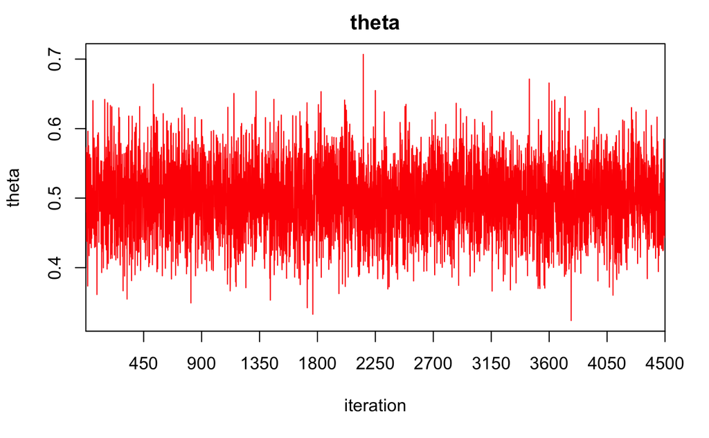

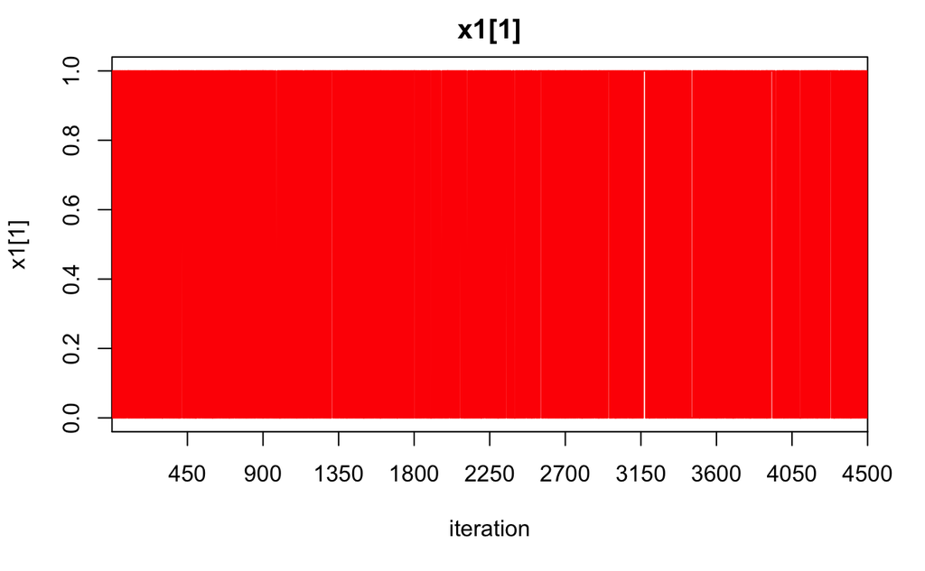

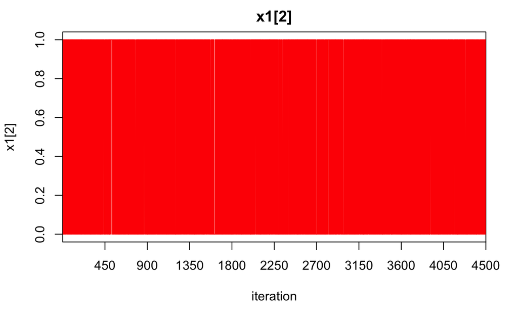

```r
#-Monitoring chain-
#Traza de la cadena
traceplot(ej1.sim)
```

La razon de esto es que no es un análisis conjugado: no estamos simulando directamente de la distribución final de manera independiente como en el inciso 1.a, sino, estamos simulando a través de la cadena.

```r
#Cadena
#JAGS
out<-ej1.sim$BUGSoutput$sims.list
z<-out$theta
par(mfrow=c(2,2))
plot(z,type="l")
plot(cumsum(z)/(1:length(z)),type="l")
```

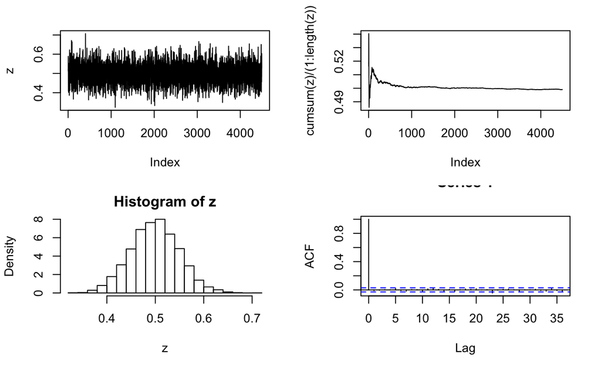

```r
hist(z,freq=FALSE)
acf(z)
```

Primer cuadro: como se está moviendo theta

Segundo: como esta convergiendo o no la media. Si se mueve mucho necesito mas iteraciones.

Tercero: Histograma de mi posterior. Si tengo “huecos” entonces necesito mas iteraciones porque hay espacios de mi parámetro que no estoy recorriendo

Cuarto: Correlacion entre las variables simulados. En este caso es 0 (dos rayas azules muy pegadas a cero)

```r
#Resumen (estimadores)
#JAGS
out.sum<-ej1.sim$BUGSoutput$summary
print(out.sum)
```

```
                mean         sd        2.5%         25%         50%         75%      97.5%
deviance 139.6444547 1.47013697 138.6305846 138.7257582 139.0705180 139.9419212 143.868021
theta      0.4990508 0.04998009   0.4014163   0.4658886   0.4990424   0.5323022   0.596677
x1[1]      0.5006667 0.50005512   0.0000000   0.0000000   1.0000000   1.0000000   1.000000
x1[2]      0.4982222 0.50005240   0.0000000   0.0000000   0.0000000   1.0000000   1.000000
```

```r
#DIC
#JAGS
out.dic<-ej1.sim$BUGSoutput$DIC
print(out.dic)
```

```
[1] 140.7251
```

ESTE RESUMEN ME DICE

Para mis datos: $x1...xn$ es una m.a. proveniente de una dist Bernoulli (exito=otorgado, fracaso=no otorgado)

Con distribuion inicial de Referencia de $\theta$ Beta(0.5,0.5)

RESULTA EN:

- La media posterior de $\theta$ no es tan precisa, porque la distribución inicial es la de referencia, es decir no sabe nada de los datos, como en los incisos a) y b), donde se tiene el conocimiento de los datos, aunque sean de distintas familias, está contenido en los parámetros a) y b) de la Beta.

- DIC: es la medida del error del modelo. Cuanto más chico mejor.

EN ESTE CASO, AL USAR LA DIST NO INFORMATIVA INICIAL, MIS ESTIMACIONES SON MENOS CERTERAS.

```
Usando el archivo Ej1_C.txt
# model: Mi modelo, distribucion de los datos  - dbin(theta,1) es una Bernoulli(theta)
#Priors - Iniciales para Theta, el parametro
#Predictive: quiero que me prediga dos futuros creditos, que también proviene de una bernoulli
#Predictiva: Esta es la forma de como decirle a JAGS que prediga

model
{
#Likelihood - Distribucion de los datos
for (i in 1:n) {
    x[i] ~ dbin(theta,1)
    }
#Priors - Iniciales para Theta, el parametro
#----------
#Inciso c
# Distribucion inicial de referencia es la Uniforme
theta ~ dbeta(0.5,0.5)
#----------
#Predictive
for (j in 1:2) {
    x1[j] ~ dbin(theta,1)
    }
}
```